# INTRODUCCIÓN Y SERIES DE TAYLOR

## Definición y clasificación

Una ecuación diferencial que involucra más de una variable independiente y sus derivadas parciales con respecto a esas variables se llama ecuación diferencial parcial (PDE).

Considere una PDE simple de la forma:

$$ \frac{\partial u(x, y)}{\partial x} =0 . $$

Esta ecuación implica que la función $u(x, y)$ es independiente de $x$. Por lo tanto, la solución general de esta ecuación es $u(x, y)=f(y)$, donde $f$ es una función arbitraria de $y$. La ecuación diferencial ordinaria análoga es:

$$ \frac{d u}{d x}=0, $$

cuya solución general es $u(x)=c$, donde $c$ es una constante. Este ejemplo ilustra que las soluciones generales de las EDO involucran constantes arbitrarias, mientras que las soluciones de las EDO involucran funciones arbitrarias.

## Clasificación de PDE

En general, se pueden clasificar las PDE con respecto a diferentes criterios, por ejemplo:

- Orden
- Dimensión
- Linealidad

$$au_{xx}+bu_{yy}+cu_{yy}+du_x+eu_y+fu+g=0$$

Se clasifican por el valor del discriminante

$$D_\lambda=b^2-4 a c$$

del problema de valores propios para la matriz

$$
A=\left(
\begin{array}{cc}
a & b / 2 \\
b / 2 & c
\end{array}
\right)
$$

construir a partir de los coeficientes de las derivadas más altas. Una clasificación simple se muestra en la siguiente tabla

| $D_\lambda$ | Tipo | Valores propios |
| --- | --- | --- |
| $D_\lambda<0$ | elíptica | mismo signo |
| $D_\lambda>0$ | hiperbólico | diferentes signos |
| $D_\lambda=0$ | parabólico | cero es un valor propio |

Por ejemplo la ecuación de Laplace

$$
\frac{\partial \phi}{\partial x^2}+\frac{\partial \phi}{\partial y^2}=0
$$

es una ecuación elíptica, porque $D_\lambda=-4<0$.

### Problemas iniciales y de valores en la frontera

La solución de PDE involucra funciones arbitrarias, por lo que para resolver completamente el sistema se necesitan condiciones adicionales. Estas condiciones se pueden dar en forma de condiciones iniciales y de contorno. Las condiciones iniciales definen los valores de las variables dependientes en la etapa inicial, mientras que las condiciones de contorno brindan información sobre el valor de la variable dependiente o su derivado en el límite del área de interés. Típicamente, se distingue:

- Las condiciones de Dirichlet especifican los valores de las variables dependientes de los puntos límite.
- Las condiciones de Neumann especifican los valores de los gradientes normales del límite.
- Las condiciones de Robin definen una combinación lineal de las condiciones de Drichlet y Neumann.

Además, es útil clasificar la PDE en cuestión en términos de problema de valor inicial (IVP) y problema de valor límite (BVP):

- Problema de valor inicial: la PDE en cuestión describe la evolución temporal, es decir, se da la distribución espacial inicial; el objetivo es encontrar cómo se propaga la variable dependiente en el tiempo.
- Problema de valores en la frontera: se debe encontrar una solución estática del problema en alguna región, y la variable dependiente se especifica en su frontera.

## Series de Taylor en una variable

Si $f(x)$ es una función de buen comportamiento* alrededor de un elegido punto de expansión $x_0$, entonces la función se puede expandir en una serie llamada serie de Taylor: $$ \begin{aligned} & f(x)=\left.\sum_{n=0}^{\infty} \frac{1}{n !} \frac{d^n f(x)}{d x^n}\right|_{x=x_0}\left(x-x_0\right)^n \\ & f(x)=f\left(x_0\right)+\left.\frac{d f(x)}{d x}\right|_{x=x_0}\left(x-x_0\right)+\left.\frac{d^2 f(x)}{2 ! d x^2}\right|_{x=x_0}\left(x-x_0\right)^2+\ldots \\ & f(x)=f\left(x_0\right)+f^{\prime}\left(x_0\right)\left(x-x_0\right)+\frac{f^{\prime \prime}\left(x_0\right)\left(x-x_0\right)^2}{2 !}+\frac{f^{(3)}\left(x_0\right)\left(x-x_0\right)^3}{3 !}+\ldots \end{aligned} $$

### Error de truncamiento

$$ f(x)=f(x_0)+ \Delta x f'(x_0)+\dots + \frac{(\Delta x)^n}{n !}f^{(n)}(x_0)+R_n $$

es la conocida **Serie de Taylor con resto**, el resto es $R_n$, tambien llamado **error de truncamiento** en un punto intermedio, que es deconocido: $$ R_n=\frac{(\Delta x)^{n+1}}{(n+1)!}f^{(n+1)}(\xi_{n+1}) \quad \text{donde} \quad x_0<\xi_{n+1}<x=x_0+\Delta x $$ para que este resultado se valido.$f(x)$ deten tener $n+1$ derivadas continuas.

#### Ejemplo: Error de truncamiento

El error de la aproximación por la tangente esta dado por la ecuación $R_n$ con $n=1$. \begin{align*} f(x +\Delta x) & =f(x_0)+ \Delta x f'(x_0)+R_n \\ & =f(x_0)+ \Delta x f'(x_0)+\frac{(\Delta x)^{n+1}}{(n+1)!}f^{(n+1)}(\xi_{n+1}) \quad \text{n=1} \\ f(x + \Delta x) & =f(x_0)+ \Delta x f'(x_0)+\frac{(\Delta x)^{2}}{2!}f^{(2)}(\xi_{2}) \end{align*} esta formula es la conocida como **teorema del valor medio extendido**.

Si $\Delta x$ es pequeño, entonces $\xi$ esta contenido en el intervalo y suponiendo que $d^2 f /dx^2$ es continua, el error de truncamiento es aproximadamente: $$R \approx \frac{(\Delta x)^2}{2}\frac{d^2 f}{dx^2}(x_0)$$. Entonces el orden del error es: \begin{align*} \left| R \right|& =\left| \frac{(\Delta x)^2}{2}\frac{d^2 f}{dx^2}(x_0) \right|=\left| \frac{(\Delta x)^2}{2} \right| \left| \frac{d^2 f}{dx^2}(x_0) \right|<\left| \frac{(\Delta x)^2}{2} \right| M\\ & <\left| \frac{(\Delta x)^2}{2} \right| M=C(\Delta x)^2 \qquad \text{con} \quad M=2C \end{align*} Esto quiere decir que "el orden del delta-x al cuadrado", lo que denotamos como $R=\mathcal{O}((\Delta x)^2)$

## Aproximaciones de la primera derivada

Aproximación de primera derivada para funciones de una variable \begin{align*} f(x + \Delta x) & =f(x_0)+ \Delta x f'(x_0)+\frac{(\Delta x)^{2}}{2!}f^{(2)}(\xi_{2}) \\ f(x + \Delta x)- f(x_0) & = \Delta x f'(x_0)+\frac{(\Delta x)^{2}}{2!}f^{(2)}(\xi_{2}) \\ f(x + \Delta x)- f(x_0)-\frac{(\Delta x)^{2}}{2!}f^{(2)}(\xi_{2}) & = \Delta x f'(x_0) \\ \frac{f(x + \Delta x)- f(x_0)-\frac{(\Delta x)^{2}}{2!}f^{(2)}(\xi_{2})}{\Delta x} & = \Delta x f'(x_0) \\ \frac{f(x + \Delta x)- f(x_0)}{\Delta x} - \frac{\Delta x}{2!}f^{(2)}(\xi_{2}) & = f'(x_0) \end{align*} tenemos: $$ \boxed{f'(x_0)=\frac{f(x + \Delta x)- f(x_0)}{\Delta x} - \frac{\Delta x}{2!}f^{(2)}(\xi_{2})} $$

Introducimos entonces una aproximación por diferencias finitas, la aproximación por **diferencias progresivas** a $\frac{df}{dx}$:

$$ \boxed{f'(x_0) \approx \frac{f(x + \Delta x)- f(x_0)}{\Delta x}} \qquad \text{diferencias progresiva} $$

Podemos sustituir $\Delta x$ por $-\Delta x$ y obtenemos la aproximación por **diferencias retrogradas** a $df/dx$ $$ \boxed{f'(x_0)=\frac{f(x - \Delta x)- f(x_0)}{-\Delta x} + \frac{\Delta x}{2!}f^{(2)}(\bar{\xi}_{2})} $$ de donde $$ \boxed{f'(x_0) \approx \frac{f(x - \Delta x)- f(x_0)}{-\Delta x}=\frac{f(x_0)-f(x - \Delta x)}{\Delta x}} \qquad \text{diferencias retrogradas} $$ Observamos que error de truncamiento de el idéntico para los tipos de diferencias y lo conveniente es sumar estas derivadas:

Sumando las aproximaciones **diferencias progresivas** y **diferencias retrogradas**

\begin{aligned} f'(x_0)+ f'(x_0) & =\frac{f(x + \Delta x)- f(x_0)}{\Delta x}-\frac{\Delta x}{2!}f^{(2)}(\bar{\xi}_{2})+ \frac{f(x_0)-f(x - \Delta x)}{\Delta x}+\frac{\Delta x}{2!}f^{(2)}(\xi_{2}) \\ 2f'(x_0) & =\frac{f(x + \Delta x)- f(x_0)}{\Delta x}+ \frac{f(x_0)-f(x - \Delta x)}{\Delta x}+\frac{\Delta x}{2!}f^{(2)}(\xi_{2})-\frac{\Delta x}{2!}f^{(2)}(\bar{\xi}_{2}) \\ 2f'(x_0) & =\frac{f(x + \Delta x)- f(x_0)+f(x_0)-f(x - \Delta x)}{\Delta x}+ \frac{\Delta x}{2!}[f^{(2)}(\xi_{2})-f^{(2)}(\bar{\xi}_{2})] \\ 2f'(x_0) & =\frac{f(x + \Delta x)-f(x - \Delta x)}{\Delta x}+ \frac{\Delta x}{2!}[f^{(2)}(\xi_{2})-f^{(2)}(\bar{\xi}_{2})] \\ \end{aligned}

Como $\bar{\xi}_2$ está cerca de $\xi_2$, esperamos que el error casi se cancele y sea mucho menor que $O(\Delta x)$. Para deducir el error en esta aproximación, volvemos a la serie de Taylor para $f\left(x_0-\Delta x\right)$ y $f\left(x_0+\Delta x\right)$

$$ \begin{aligned} & f\left(x_0+\Delta x\right)=f\left(x_0\right)+\Delta x f^{\prime}\left(x_0\right)+\frac{(\Delta x)^2}{2 !} f^{\prime \prime}\left(x_0\right)+\frac{(\Delta x)^3}{3 !} f^{\prime \prime \prime}\left(x_0\right)+\cdots \\ & f\left(x_0-\Delta x\right)=f\left(x_0\right)-\Delta x f^{\prime}\left(x_0\right)+\frac{(\Delta x)^2}{2 !} f^{\prime \prime}\left(x_0\right)-\frac{(\Delta x)^3}{3 !} f^{\prime \prime \prime}\left(x_0\right)+\cdots \end{aligned} $$

Restando las anteriores, nos queda $$ f\left(x_0+\Delta x\right)-f\left(x_0-\Delta x\right)=2 \Delta x f^{\prime}\left(x_0\right)+\frac{2}{3 !}(\Delta x)^3 f^{\prime \prime \prime}\left(x_0\right)+\cdots $$ Luego esperamos que $$ f^{\prime}\left(x_0\right)=\frac{f\left(x_0+\Delta x\right)-f\left(x_0-\Delta x\right)}{2 \Delta x}-\frac{(\Delta x)^2}{6} f^{\prime \prime \prime}\left(\xi_3\right) $$ fórmula que se prueba en un ejercicio. Esto nos lleva a la aproximación por **diferencias centradas** de $d f / d x\left(x_0\right)$:

$$ \boxed{ f^{\prime}\left(x_0\right) \approx \frac{f\left(x_0+\Delta x\right)-f\left(x_0-\Delta x\right)}{2 \Delta x} \qquad \text{Diferencias Centradas} } $$

La ecuación es normalmente la preferida, ya que es mas precisa en el sentido de que el error de truncamiento es $R=\mathcal{O}((\Delta x)^2)$. Estas aproximaciones por diferencias finitas a $df/dx$ son consistentes, lo que significa que el error de truncamiento se anulan cuando $\Delta x \rightarrow 0 $.

#### Ejemplo: Aproximación para $f(x)=\ln(x)$

Aproximación de la derivada de $f(x)=\ln(x)$ en $x=1$ y utilizando $\Delta x = 0.1$.

**Respuestas**:

*Exacta*: $$D_x (\ln(x))|_{x=1}=\frac{1}{x}|_{x=1}=1$$

```julia
Δ𝑥=0.1 ; 𝑥0=1 ;
```

*Diferencias progresiva* $$ \boxed{f'(x_0) \approx \frac{f(x + \Delta x)- f(x_0)}{\Delta x}} $$

```julia
dp=(log(Δ𝑥+𝑥0)-log(𝑥0))/Δ𝑥
```

```
0.9531017980432493
```

```julia
Errordp=abs(dp-1)*100
```

```
4.689820195675065
```

*Diferencias retrogradas* $$ \boxed{f'(x_0) \approx \frac{f(x_0)-f(x - \Delta x)}{\Delta x}} $$

```julia
dr=(log(𝑥0)-log(𝑥0-Δ𝑥))/Δ𝑥
```

```
1.0536051565782627
```

```julia
Errordr=abs(dr-1)*100
```

```
5.36051565782627
```

*Diferencias Centradas* $$ \boxed{ f^{\prime}\left(x_0\right) \approx \frac{f\left(x_0+\Delta x\right)-f\left(x_0-\Delta x\right)}{2 \Delta x} } $$

```julia
dc=(log(Δ𝑥+𝑥0)-log(𝑥0-Δ𝑥))/2Δ𝑥
```

```
1.003353477310756
```

```julia
Errordc=abs(dc-1)*100
```

```
0.335347731075597
```

|  | Solución exacta | Diferencias progresivas | Diferencias retrogradas | Diferencias centradas |
| --- | --- | --- | --- | --- |
| Valor | 1 | 0.9531017980432493 | 1.0536051565782627 | 1.003353477310756 |
| Error | 0% | 4.689820195675065% | 5.36051565782627% | 0.335347731075597% |

Se ilustra muy bien como las diferencias centradas se aproximan mejor al valor verdadero de la derivada.

## Aproximaciones de la segunda derivada

$$ f\left(x_0+\Delta x\right)+f\left(x_0-\Delta x\right)=2 f\left(x_0\right)+(\Delta x)^2 f^{\prime \prime}\left(x_0\right)+\frac{2(\Delta x)^4}{4 !} f^{(i v)}\left(x_0\right)+\cdots $$

Luego esperamos que $$ f^{\prime \prime}\left(x_0\right)=\frac{f\left(x_0+\Delta x\right)-2 f\left(x_0\right)+f\left(x_0-\Delta x\right)}{(\Delta x)^2}-\frac{(\Delta x)^2}{12} f^{(i v)}(\xi) . $$ Esto nos da una aproximación por diferencias finitas para la segunda derivada con error de truncamiento $O(\Delta x)^2$ : $$ \frac{d^2 f}{d x^2}\left(x_0\right) \approx \frac{f\left(x_0+\Delta x\right)-2 f\left(x_0\right)+f\left(x_0-\Delta x\right)}{(\Delta x)^2} $$

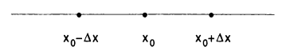

tenemos la aproximación:

$$ \frac{\partial^2 u}{\partial x^2} \approx \frac{u(x+ \Delta x)-2u(x)+u(x- \Delta x)}{ \Delta x^2} $$

## Derivadas Parciales

Al resolver ecuaciones en derivadas parciales, analizamos funciones de dos o más variables, por ejemplo, $u(x, y), u(x, t)$ y $u(x, y, t)$.

Los métodos numéricos utilizan a menudo aproximaciones por diferencias finitas. Algunas derivadas parciales (pero no todas) se pueden obtener usando nuestros resultados anteriores para funciones de una variable. Por ejemplo, para una función $u(x, y)$, la derivada parcial $\partial u / \partial x$ es, en realidad, una derivada ordinaria $d u / d x$ si mantenemos $y$ fijo. Por tanto podemos utilizar así las fórmulas de diferencia progresivas, retrógradas o centradas. Usando la fórmula de diferencias centradas, por ejemplo, se tiene

$$ \frac{\partial u}{\partial x}\left(x_0, y_0\right) \approx \frac{u\left(x_0+\Delta x, y_0\right)-u\left(x_0-\Delta x, y_0\right)}{2 \Delta x} . $$

Para la derivada $\partial u / \partial y$ mantenemos $x$ fijo y obtenemos

$$ \frac{\partial u}{\partial y}\left(x_0, y_0\right) \approx \frac{u\left(x_0, y_0+\Delta y\right)-u\left(x_0, y_0-\Delta y\right)}{2 \Delta y} $$

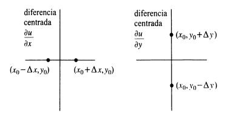

### Ejercicio.

Deducir una aproximación para $\frac{\partial^2 u}{\partial x \partial y}$ cuyo error de truncamiento sea $O(\Delta x)^2$.

\begin{gathered} \frac{\partial^2 u}{\partial x \partial y}=\frac{\partial}{\partial y}\left(\frac{\partial u}{\partial x}\right)=\frac{\partial}{\partial y} \frac{u(x+\Delta x, y)-u(x-\Delta x, y)}{2 \Delta x} \\ \end{gathered}

\begin{aligned} \frac{\partial^2 u}{\partial x \partial y} & = \frac{\partial}{\partial y} \frac{u(x+\Delta x, y)-u(x-\Delta x, y)}{2 \Delta x} \\ \end{aligned}

\begin{aligned} \frac{\partial^2 u}{\partial x \partial y} & =\frac{1}{2 \Delta x} \frac{\partial}{\partial y}[u(x+\Delta x, y)-u(x-\Delta x, y)] \\ \end{aligned}

\begin{aligned} \frac{\partial^2 u}{\partial x \partial y} & =\frac{1}{2 \Delta x}[\frac{\partial}{\partial y}u(x+\Delta x, y)-\frac{\partial}{\partial y}u(x-\Delta x, y)] \\ \end{aligned}

Mantenemos fijo $x+\Delta x$ y aplicamos derivada parcial respecto a $y$ para las funciones $u(x+\Delta x,y)$ y $u(x-\Delta x,y)$, teneemos:

$$ \frac{\partial u}{\partial y}\left(x+\Delta x, y\right) \approx \frac{u\left(x+\Delta x, y+\Delta y\right)-u\left(x+\Delta x, y-\Delta y\right)}{2 \Delta y} $$

$$ \frac{\partial u}{\partial y}\left(x-\Delta x, y\right) \approx \frac{u\left(x-\Delta x, y+\Delta y\right)-u\left(x-\Delta x, y-\Delta y\right)}{2 \Delta y} $$

Remplazando tenemos:

\begin{aligned} \frac{\partial^2 u}{\partial x \partial y} & =\frac{1}{2 \Delta x}[\frac{u\left(x+\Delta x, y+\Delta y\right)-u\left(x+\Delta x, y-\Delta y\right)}{2 \Delta y}-\frac{u\left(x-\Delta x, y+\Delta y\right)-u\left(x-\Delta x, y-\Delta y\right)}{2 \Delta y}] \\ \end{aligned}

\begin{aligned} \frac{\partial^2 u}{\partial x \partial y} & =\frac{1}{2 \Delta x}[\frac{u\left(x+\Delta x, y+\Delta y\right)-u\left(x+\Delta x, y-\Delta y\right)-u\left(x-\Delta x, y+\Delta y\right)+u\left(x-\Delta x, y-\Delta y\right)}{2 \Delta y}] \\ \frac{\partial^2 u}{\partial x \partial y} & =\frac{1}{4 \Delta x \Delta y}[u\left(x+\Delta x, y+\Delta y\right)-u\left(x+\Delta x, y-\Delta y\right)-u\left(x-\Delta x, y+\Delta y\right)+u\left(x-\Delta x, y-\Delta y\right)] \end{aligned}

## Series de Taylor en varias variables

La serie de Taylor se puede generalizar a funciones de más de una variable como $$ \begin{aligned} f\left(x_1, \ldots, x_d\right) & =\sum_{n_1=0}^{\infty} \cdots \sum_{n_d=0}^{\infty} \frac{\left(x_1-a_1\right)^{n_1} \cdots\left(x_d-a_d\right)^{n_d}}{n_{1} ! \cdots n_{d} !}\left(\frac{\partial^{n_1+\cdots+n_d} }{\partial x_1^{n_1} \cdots \partial x_d^{n_d}}\right) f \left(a_1, \ldots, a_d\right) \\ & =f\left(a_1, \ldots, a_d\right)+\sum_{j=1}^d \frac{\partial f\left(a_1, \ldots, a_d\right)}{\partial x_j}\left(x_j-a_j\right) \\ & +\frac{1}{2 !} \sum_{j=1}^d \sum_{k=1}^d \frac{\partial^2 f\left(a_1, \ldots, a_d\right)}{\partial x_j \partial x_k}\left(x_j-a_j\right)\left(x_k-a_k\right) \\ & +\frac{1}{3 !} \sum_{j=1}^d \sum_{k=1}^d \sum_{\varphi=1}^d \frac{\partial^3 f\left(a_1, \ldots, a_d\right)}{\partial x_j \partial x_k \partial x_{\varphi}}\left(x_j-a_j\right)\left(x_k-a_k\right)\left(x_{\varphi}-a_{\varphi}\right)+\cdots \end{aligned} $$ Como ejemplo, para una función de 2 variables $f(x, y)$, la serie de Taylor de segundo orden alrededor del punto $(a, b)$ es: \begin{align*} f(x, y)&= f(a, b)+f_x(a, b)(x-a)+f_y(a, b)(y-b) \\ & +\frac{1}{2}\left(f_{x x}(a, b)(x-a)^2+2 f_{x y}(a, b)(x-a)(y-b)+f_{y y}(a, b)(y-b)^2\right) \end{align*} donde los subíndices denotan las respectivas derivadas parciales, esto es \begin{align*} f(x, y)&= f(a, b)+\frac{\partial f(a, b)}{\partial x}(x-a)+\frac{\partial f(a, b)}{\partial y}(y-b)\\ & +\frac{1}{2}\left(\frac{\partial^2 f(a, b)}{\partial x^2}(x-a)^2+2 \frac{\partial^2 f(a, b)}{\partial x \partial y}(x-a)(y-b)+\frac{\partial^2 f(a, b)}{\partial y^2}(y-b)^2\right) \end{align*}

Una expansión en serie Taylor de segundo orden para funciones escalares de más de una variable puede ser escrito de manera compacta como $$ T(\mathbf{x})=f(\mathbf{a})+(\mathbf{x}-\mathbf{a})^T D f(\mathbf{a})+\frac{1}{2}(\mathbf{x}-\mathbf{a})^T D^2 f(\mathbf{a})(\mathbf{x}-\mathbf{a})+\cdots $$ donde $D f(\mathbf{a})$ es el gradiente de $f$ en $\mathbf{x}=\mathbf{a}$ y $D^2 f(\mathbf{a})$ es la matriz hessiana. Otra forma: $$ T(\mathbf{x})=\sum_{|\alpha| \geq 0} \frac{D^\alpha f(\mathbf{a})}{\alpha !}(\mathbf{x}-\mathbf{a})^\alpha $$